# cd3

Foundation of Machine Learning (Section 2, Group 20)

Group Name :- Final Project 20

Submitted By : - Shubham Prajapati(8945201), Harsh Dhamaliya(8926600)

Guided By :- Mr. Ran Feldesh

Dataset from Kaggle Reference COVID19 Global Forecasting (Week 1) : - https://www.kaggle.com/competitions/covid19-global-forecasting-week-1/data

# EDA Process to get insights of Data provided

The data is already divided into test and train datasets. So We are using train dataset to perform EDA.

```python
# manipulation data
import pandas as pd
import numpy as np

#visualiation data
import matplotlib.pyplot as plt
import seaborn as sns
import matplotlib
import plotly.graph_objects as go
import plotly.express as px
import plotly.graph_objects as go
from plotly.offline import init_notebook_mode, iplot


#from dataprep.eda import *
#from dataprep.datasets import load_dataset
#from dataprep.eda import create_report

from sklearn.model_selection import cross_val_score
from sklearn.model_selection import train_test_split
from sklearn.pipeline import Pipeline
from sklearn.preprocessing import StandardScaler
from sklearn.metrics import mean_squared_error
from sklearn.metrics import r2_score
from sklearn.preprocessing import PolynomialFeatures

from sklearn.model_selection import GridSearchCV

import math


from sklearn.linear_model import LinearRegression
from sklearn.linear_model import Lasso
from sklearn.tree import DecisionTreeRegressor
from sklearn.ensemble import RandomForestRegressor
from xgboost import XGBRegressor
from sklearn.linear_model import SGDRegressor



import datetime as dt
```

## Plot Styling with Seaborn and Matplotlib

```python
# Setting Seaborn style and color palette
sns.set(context='notebook', style='darkgrid', palette='Spectral', font='sans-serif', font_scale=1, rc=None)

# Setting Matplotlib figure size
plt.rcParams['figure.figsize'] = [8, 8]

# Updating Matplotlib font size
plt.rcParams.update({'font.size': 15})

# Setting Matplotlib font family
plt.rcParams['font.family'] = 'sans-serif'
```

## Reading and Displaying Datasets

```python
# Reading the training dataset
train_df = pd.read_csv(r"D:\CLG\Foundation of Machine Learning\pROJ\Covid-19-Case-Prediction\Dataset\train.csv")

# Reading the testing dataset
test_df = pd.read_csv(r"D:\CLG\Foundation of Machine Learning\pROJ\Covid-19-Case-Prediction\Dataset\test.csv")
```

```python
# Displaying the training dataset
train_df
```

|  | Id | County | Province_State | Country_Region | Population | Weight | Date | Target | TargetValue |
| --- | --- | --- | --- | --- | --- | --- | --- | --- | --- |
| 0 | 1 | NaN | NaN | Afghanistan | 27657145 | 0.058359 | 2020-01-23 | ConfirmedCases | 0 |
| 1 | 2 | NaN | NaN | Afghanistan | 27657145 | 0.583587 | 2020-01-23 | Fatalities | 0 |
| 2 | 3 | NaN | NaN | Afghanistan | 27657145 | 0.058359 | 2020-01-24 | ConfirmedCases | 0 |
| 3 | 4 | NaN | NaN | Afghanistan | 27657145 | 0.583587 | 2020-01-24 | Fatalities | 0 |
| 4 | 5 | NaN | NaN | Afghanistan | 27657145 | 0.058359 | 2020-01-25 | ConfirmedCases | 0 |
| ... | ... | ... | ... | ... | ... | ... | ... | ... | ... |
| 969635 | 969636 | NaN | NaN | Zimbabwe | 14240168 | 0.607106 | 2020-06-08 | Fatalities | 0 |
| 969636 | 969637 | NaN | NaN | Zimbabwe | 14240168 | 0.060711 | 2020-06-09 | ConfirmedCases | 27 |
| 969637 | 969638 | NaN | NaN | Zimbabwe | 14240168 | 0.607106 | 2020-06-09 | Fatalities | 0 |
| 969638 | 969639 | NaN | NaN | Zimbabwe | 14240168 | 0.060711 | 2020-06-10 | ConfirmedCases | 6 |
| 969639 | 969640 | NaN | NaN | Zimbabwe | 14240168 | 0.607106 | 2020-06-10 | Fatalities | 0 |

969640 rows × 9 columns

```python
# Displaying the testing dataset
test_df
```

|  | ForecastId | County | Province_State | Country_Region | Population | Weight | Date | Target |
| --- | --- | --- | --- | --- | --- | --- | --- | --- |
| 0 | 1 | NaN | NaN | Afghanistan | 27657145 | 0.058359 | 2020-04-27 | ConfirmedCases |
| 1 | 2 | NaN | NaN | Afghanistan | 27657145 | 0.583587 | 2020-04-27 | Fatalities |
| 2 | 3 | NaN | NaN | Afghanistan | 27657145 | 0.058359 | 2020-04-28 | ConfirmedCases |
| 3 | 4 | NaN | NaN | Afghanistan | 27657145 | 0.583587 | 2020-04-28 | Fatalities |
| 4 | 5 | NaN | NaN | Afghanistan | 27657145 | 0.058359 | 2020-04-29 | ConfirmedCases |
| ... | ... | ... | ... | ... | ... | ... | ... | ... |
| 311665 | 311666 | NaN | NaN | Zimbabwe | 14240168 | 0.607106 | 2020-06-08 | Fatalities |
| 311666 | 311667 | NaN | NaN | Zimbabwe | 14240168 | 0.060711 | 2020-06-09 | ConfirmedCases |
| 311667 | 311668 | NaN | NaN | Zimbabwe | 14240168 | 0.607106 | 2020-06-09 | Fatalities |
| 311668 | 311669 | NaN | NaN | Zimbabwe | 14240168 | 0.060711 | 2020-06-10 | ConfirmedCases |
| 311669 | 311670 | NaN | NaN | Zimbabwe | 14240168 | 0.607106 | 2020-06-10 | Fatalities |

311670 rows × 8 columns

The dataset has following columns

1. ID
2. County
3. Province_State
4. Country_Region
5. Population
6. Weight
7. Date
8. Target
9. TargetValuu

From the first view of the dataset, we can say that to predict the target values i.e, the number of fatalities and confirmed cases, some data is not that usefull. Fro example, County, Province_State and Country_Region does not take much part in Learning process and we can remove them at the time of selecting features. But before decideing, let's have deeper look at the dataset.

```python
# Displaying Information about the Training Dataset
train_df.info()
```

```
<class 'pandas.core.frame.DataFrame'>
RangeIndex: 969640 entries, 0 to 969639
Data columns (total 9 columns):
 #   Column          Non-Null Count   Dtype
---  ------          --------------   -----
 0   Id              969640 non-null  int64
 1   County          880040 non-null  object
 2   Province_State  917280 non-null  object
 3   Country_Region  969640 non-null  object
 4   Population      969640 non-null  int64
 5   Weight          969640 non-null  float64
 6   Date            969640 non-null  object
 7   Target          969640 non-null  object
 8   TargetValue     969640 non-null  int64
dtypes: float64(1), int64(3), object(5)
memory usage: 66.6+ MB
```

```python
# Displaying the Shape of the Training Dataset
train_df.shape
```

```
(969640, 9)
```

From the shape function, we now know that there are total of 969640 number of rows in training dataset initially.

```python
# Displaying Data Type Counts in the Training Dataset
train_df.dtypes.value_counts()
```

```
object     5
int64      3
float64    1
Name: count, dtype: int64
```

As far as the datatypes are concirned, We have 1 column with float value, 3 columns with integer value and 5 columns with object values. The destibution of which can be seen in the pie chart below.

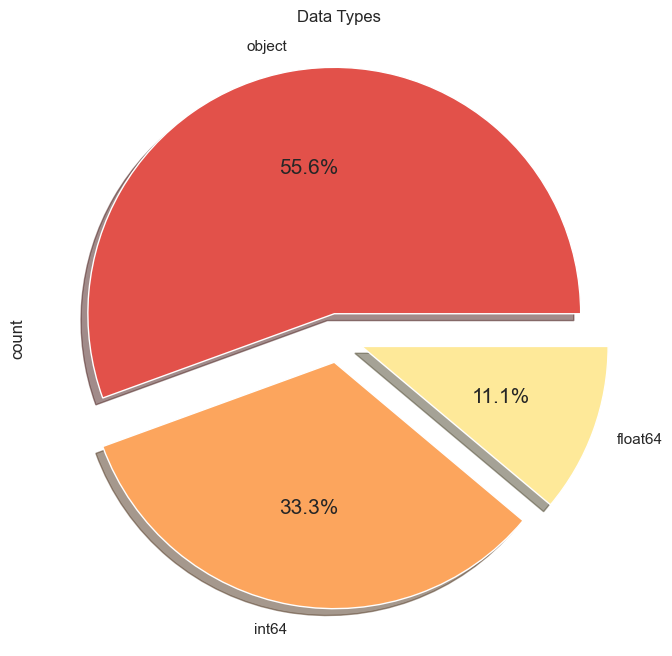

```python
# Pie Chart of Data Type Distribution in the Training Dataset
train_df.dtypes.value_counts().plot.pie(explode=[0.1,0.1,0.1],autopct='%1.1f%%',shadow=True)
plt.title('Data Types')
```

```python
# Summary Statistics for the Training Dataset
train_df.describe(include="all")
```

|  | Id | County | Province_State | Country_Region | Population | Weight | Date | Target | TargetValue |
| --- | --- | --- | --- | --- | --- | --- | --- | --- | --- |
| count | 969640.000000 | 880040 | 917280 | 969640 | 9.696400e+05 | 969640.000000 | 969640 | 969640 | 969640.000000 |
| unique | NaN | 1840 | 133 | 187 | NaN | NaN | 140 | 2 | NaN |
| top | NaN | Washington | Texas | US | NaN | NaN | 2020-01-23 | ConfirmedCases | NaN |
| freq | NaN | 8680 | 71400 | 895440 | NaN | NaN | 6926 | 484820 | NaN |
| mean | 484820.500000 | NaN | NaN | NaN | 2.720127e+06 | 0.530870 | NaN | NaN | 12.563518 |
| std | 279911.101846 | NaN | NaN | NaN | 3.477771e+07 | 0.451909 | NaN | NaN | 302.524795 |
| min | 1.000000 | NaN | NaN | NaN | 8.600000e+01 | 0.047491 | NaN | NaN | -10034.000000 |
| 25% | 242410.750000 | NaN | NaN | NaN | 1.213300e+04 | 0.096838 | NaN | NaN | 0.000000 |
| 50% | 484820.500000 | NaN | NaN | NaN | 3.053100e+04 | 0.349413 | NaN | NaN | 0.000000 |
| 75% | 727230.250000 | NaN | NaN | NaN | 1.056120e+05 | 0.968379 | NaN | NaN | 0.000000 |
| max | 969640.000000 | NaN | NaN | NaN | 1.395773e+09 | 2.239186 | NaN | NaN | 36163.000000 |

```python
# Count of Missing Values in the Training Dataset
train_df.isnull().sum()
```

```
Id                    0
County            89600
Province_State    52360
Country_Region        0
Population            0
Weight                0
Date                  0
Target                0
TargetValue           0
dtype: int64
```

```python
# DataFrame with Missing Values Information
missing_perc = train_df.isnull().sum()/train_df.shape[0]*100
d = {
    'missing': train_df.isnull().sum(),
    'percentage': missing_perc
}
df = pd.DataFrame(d)
df
```

|  | missing | percentage |
| --- | --- | --- |
| Id | 0 | 0.000000 |
| County | 89600 | 9.240543 |
| Province_State | 52360 | 5.399942 |
| Country_Region | 0 | 0.000000 |
| Population | 0 | 0.000000 |
| Weight | 0 | 0.000000 |
| Date | 0 | 0.000000 |
| Target | 0 | 0.000000 |
| TargetValue | 0 | 0.000000 |

```python
# Date Information in the Training Dataset
print(f"minimum date {min(train_df['Date'])}")
print(f"maximum date {max(train_df['Date'])}")
print(f"Total Days {train_df['Date'].nunique()}")
```

```
minimum date 2020-01-23
maximum date 2020-06-10
Total Days 140
```

```
array([[<Axes: title={'center': 'Id'}>,
        <Axes: title={'center': 'Population'}>],
       [<Axes: title={'center': 'Weight'}>,
        <Axes: title={'center': 'TargetValue'}>]], dtype=object)
```

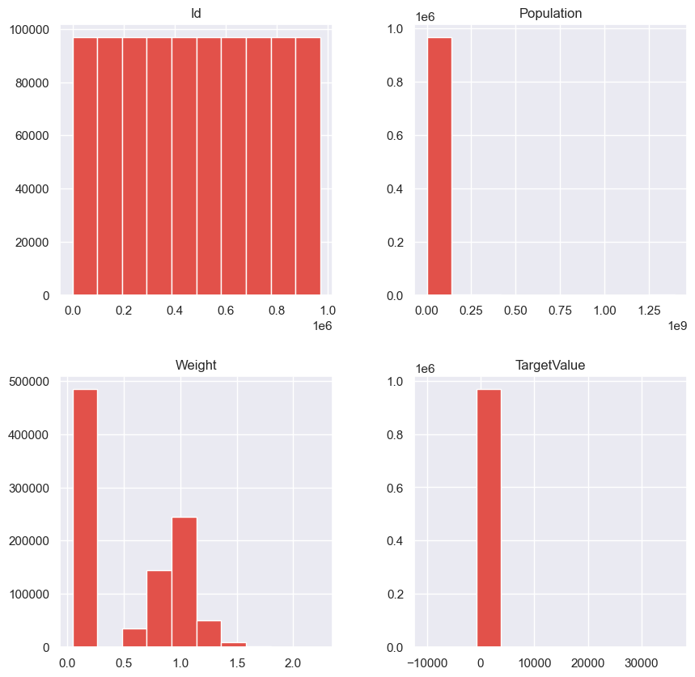

```python
# Histograms for Numerical Columns in the Training Dataset
train_df.hist(figsize=(10,10)) #plotting only numerical data
```

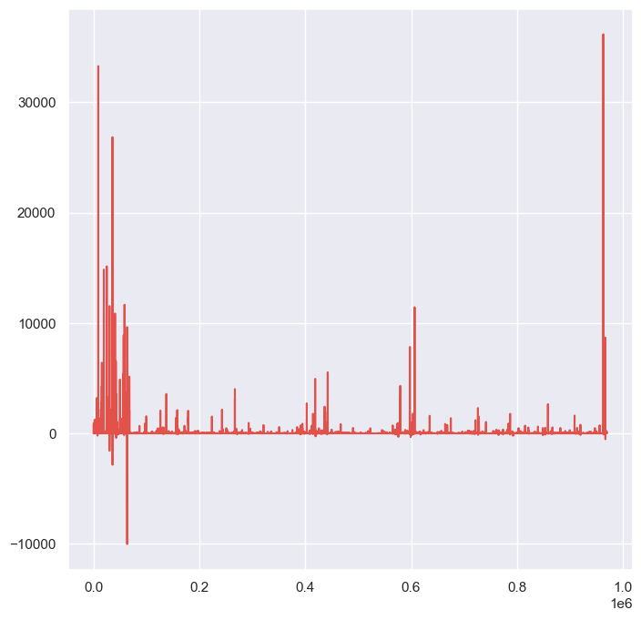

```python
# Line Plot for the 'TargetValue' Column in the Training Dataset
plt.plot(train_df.TargetValue)
```

```python
# Pie Chart for TargetValue with respect to Target
# Pie Chart for 'TargetValue' in the Training Dataset
fig = px.pie(train_df,values="TargetValue",names='Target')
fig.update_traces(textposition='outside')
fig.show()
```

```python
# Pie Chart for 'TargetValue' Distribution Across Countries/Regions
fig = px.pie(train_df,values="TargetValue",names="Country_Region")
fig.update_traces(textposition='inside')
fig.show()
```

```python
# Visualization of Unique Population Values
train_df.Population.value_counts()# we can add country data per cases visualization before this
```

```
Population
14651       840
2530        840
2356        560
19983       560
2013        560
           ...
9564        280
66911       280
2648        280
3250        280
14240168    280
Name: count, Length: 3408, dtype: int64
```

```python
# Counting Unique Values in the 'Target' Column
train_df.Target.value_counts()
```

```
Target
ConfirmedCases    484820
Fatalities        484820
Name: count, dtype: int64
```

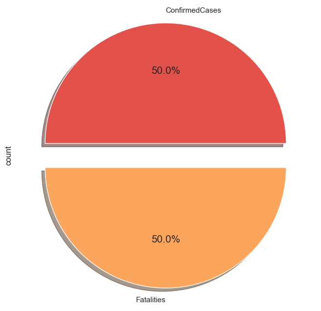

```python
# Creating Pie Chart for the Distribution of 'Target' Values
train_df.Target.value_counts().plot.pie(explode=[0.1,0.1], autopct='%1.1f%%',shadow=True)
```

```python
# Filtering data for the last date and top 10 countries
last_date = train_df.Date.max()
df_countries = train_df[train_df['Date']==last_date]
df_countries = df_countries.groupby('Country_Region',as_index=False)['TargetValue'].sum()
df_countries = df_countries.nlargest(10,'TargetValue')

# Creating a trend dataframe
df_trend = train_df.groupby(['Date','Country_Region'],as_index=False)['TargetValue'].sum()
df_trend = df_trend.merge(df_countries,on='Country_Region')
df_trend.rename(columns={'Country_Region':'Country','TargetValue_x':'Cases'},inplace=True)
```

```python
# Lining Plot for COVID-19 Total Cases Growth
px.line(df_trend, x='Date', y='Cases', color='Country', title='COVID19 Total Cases growth for top 10 worst affected countries')
```

```python
# Filtering Data for Top 10 Countries by Total Cases and Merging with Overall Trend Data
last_date_ = train_df.Date.max()
df_countries_ = train_df[train_df['Date']==last_date_]
df_countries_ = df_countries_.groupby('Country_Region',as_index=False)['TargetValue'].sum()
df_countries_ = df_countries_.nlargest(10,'TargetValue')
df_trend_ = train_df.groupby(['Population','Country_Region'],as_index=False)['TargetValue'].sum()
df_trend_ = df_trend_.merge(df_countries,on='Country_Region')
```

```python
# Creating Line Plot for COVID-19 Total Cases Growth Relative to Population
px.line(df_trend_, x='Country_Region', y='Population', title='COVID19 Total Cases growth for top 10 worst affected countries with respect to population')
```

```python
#dropping unwanted columns
df = train_df.drop(['County','Province_State'],axis=1)

df
```

|  | Id | Country_Region | Population | Weight | Date | Target | TargetValue |
| --- | --- | --- | --- | --- | --- | --- | --- |
| 0 | 1 | Afghanistan | 27657145 | 0.058359 | 2020-01-23 | ConfirmedCases | 0 |
| 1 | 2 | Afghanistan | 27657145 | 0.583587 | 2020-01-23 | Fatalities | 0 |
| 2 | 3 | Afghanistan | 27657145 | 0.058359 | 2020-01-24 | ConfirmedCases | 0 |
| 3 | 4 | Afghanistan | 27657145 | 0.583587 | 2020-01-24 | Fatalities | 0 |
| 4 | 5 | Afghanistan | 27657145 | 0.058359 | 2020-01-25 | ConfirmedCases | 0 |
| ... | ... | ... | ... | ... | ... | ... | ... |
| 969635 | 969636 | Zimbabwe | 14240168 | 0.607106 | 2020-06-08 | Fatalities | 0 |
| 969636 | 969637 | Zimbabwe | 14240168 | 0.060711 | 2020-06-09 | ConfirmedCases | 27 |
| 969637 | 969638 | Zimbabwe | 14240168 | 0.607106 | 2020-06-09 | Fatalities | 0 |
| 969638 | 969639 | Zimbabwe | 14240168 | 0.060711 | 2020-06-10 | ConfirmedCases | 6 |
| 969639 | 969640 | Zimbabwe | 14240168 | 0.607106 | 2020-06-10 | Fatalities | 0 |

969640 rows × 7 columns

```python
# Checking for Missing Values
df.isnull().sum()
```

```
Id                0
Country_Region    0
Population        0
Weight            0
Date              0
Target            0
TargetValue       0
dtype: int64
```

```python
# Creating dummy variables for the 'Target' column
dummies = pd.get_dummies(df.Target)

# Creating dummy variables for the 'Country_Region' column
dummies_country = pd.get_dummies(df.Country_Region)
```

```python
# Merging Original DataFrame with Dummy Variables

# Merging with dummy variables for the 'Target' column
mergerd = pd.concat([df,dummies],axis='columns')

# Merging with dummy variables for the 'Country_Region' column
merged = pd.concat([mergerd,dummies_country],axis= 'columns')
mergerd
```

|  | Id | Country_Region | Population | Weight | Date | Target | TargetValue | ConfirmedCases | Fatalities |
| --- | --- | --- | --- | --- | --- | --- | --- | --- | --- |
| 0 | 1 | Afghanistan | 27657145 | 0.058359 | 2020-01-23 | ConfirmedCases | 0 | True | False |
| 1 | 2 | Afghanistan | 27657145 | 0.583587 | 2020-01-23 | Fatalities | 0 | False | True |
| 2 | 3 | Afghanistan | 27657145 | 0.058359 | 2020-01-24 | ConfirmedCases | 0 | True | False |
| 3 | 4 | Afghanistan | 27657145 | 0.583587 | 2020-01-24 | Fatalities | 0 | False | True |
| 4 | 5 | Afghanistan | 27657145 | 0.058359 | 2020-01-25 | ConfirmedCases | 0 | True | False |
| ... | ... | ... | ... | ... | ... | ... | ... | ... | ... |
| 969635 | 969636 | Zimbabwe | 14240168 | 0.607106 | 2020-06-08 | Fatalities | 0 | False | True |
| 969636 | 969637 | Zimbabwe | 14240168 | 0.060711 | 2020-06-09 | ConfirmedCases | 27 | True | False |
| 969637 | 969638 | Zimbabwe | 14240168 | 0.607106 | 2020-06-09 | Fatalities | 0 | False | True |
| 969638 | 969639 | Zimbabwe | 14240168 | 0.060711 | 2020-06-10 | ConfirmedCases | 6 | True | False |
| 969639 | 969640 | Zimbabwe | 14240168 | 0.607106 | 2020-06-10 | Fatalities | 0 | False | True |

969640 rows × 9 columns

```python
# Dropping specified columns from the merged DataFrame
df_without_text_target = merged.drop(['Target','Afghanistan','Country_Region'],axis=1)
df_without_text_target
```

|  | Id | Population | Weight | Date | TargetValue | ConfirmedCases | Fatalities | Albania | Algeria | Andorra | ... | United Kingdom | Uruguay | Uzbekistan | Venezuela | Vietnam | West Bank and Gaza | Western Sahara | Yemen | Zambia | Zimbabwe |
| --- | --- | --- | --- | --- | --- | --- | --- | --- | --- | --- | --- | --- | --- | --- | --- | --- | --- | --- | --- | --- | --- |
| 0 | 1 | 27657145 | 0.058359 | 2020-01-23 | 0 | True | False | False | False | False | ... | False | False | False | False | False | False | False | False | False | False |
| 1 | 2 | 27657145 | 0.583587 | 2020-01-23 | 0 | False | True | False | False | False | ... | False | False | False | False | False | False | False | False | False | False |
| 2 | 3 | 27657145 | 0.058359 | 2020-01-24 | 0 | True | False | False | False | False | ... | False | False | False | False | False | False | False | False | False | False |
| 3 | 4 | 27657145 | 0.583587 | 2020-01-24 | 0 | False | True | False | False | False | ... | False | False | False | False | False | False | False | False | False | False |
| 4 | 5 | 27657145 | 0.058359 | 2020-01-25 | 0 | True | False | False | False | False | ... | False | False | False | False | False | False | False | False | False | False |
| ... | ... | ... | ... | ... | ... | ... | ... | ... | ... | ... | ... | ... | ... | ... | ... | ... | ... | ... | ... | ... | ... |
| 969635 | 969636 | 14240168 | 0.607106 | 2020-06-08 | 0 | False | True | False | False | False | ... | False | False | False | False | False | False | False | False | False | True |
| 969636 | 969637 | 14240168 | 0.060711 | 2020-06-09 | 27 | True | False | False | False | False | ... | False | False | False | False | False | False | False | False | False | True |
| 969637 | 969638 | 14240168 | 0.607106 | 2020-06-09 | 0 | False | True | False | False | False | ... | False | False | False | False | False | False | False | False | False | True |
| 969638 | 969639 | 14240168 | 0.060711 | 2020-06-10 | 6 | True | False | False | False | False | ... | False | False | False | False | False | False | False | False | False | True |
| 969639 | 969640 | 14240168 | 0.607106 | 2020-06-10 | 0 | False | True | False | False | False | ... | False | False | False | False | False | False | False | False | False | True |

969640 rows × 193 columns

```python
# Droping one dummy variable column ('Fatalities') to avoid dummy variable trap
df_final = df_without_text_target.drop(['Fatalities'],axis='columns')
df_final
```

|  | Id | Population | Weight | Date | TargetValue | ConfirmedCases | Albania | Algeria | Andorra | Angola | ... | United Kingdom | Uruguay | Uzbekistan | Venezuela | Vietnam | West Bank and Gaza | Western Sahara | Yemen | Zambia | Zimbabwe |
| --- | --- | --- | --- | --- | --- | --- | --- | --- | --- | --- | --- | --- | --- | --- | --- | --- | --- | --- | --- | --- | --- |
| 0 | 1 | 27657145 | 0.058359 | 2020-01-23 | 0 | True | False | False | False | False | ... | False | False | False | False | False | False | False | False | False | False |
| 1 | 2 | 27657145 | 0.583587 | 2020-01-23 | 0 | False | False | False | False | False | ... | False | False | False | False | False | False | False | False | False | False |
| 2 | 3 | 27657145 | 0.058359 | 2020-01-24 | 0 | True | False | False | False | False | ... | False | False | False | False | False | False | False | False | False | False |
| 3 | 4 | 27657145 | 0.583587 | 2020-01-24 | 0 | False | False | False | False | False | ... | False | False | False | False | False | False | False | False | False | False |
| 4 | 5 | 27657145 | 0.058359 | 2020-01-25 | 0 | True | False | False | False | False | ... | False | False | False | False | False | False | False | False | False | False |
| ... | ... | ... | ... | ... | ... | ... | ... | ... | ... | ... | ... | ... | ... | ... | ... | ... | ... | ... | ... | ... | ... |
| 969635 | 969636 | 14240168 | 0.607106 | 2020-06-08 | 0 | False | False | False | False | False | ... | False | False | False | False | False | False | False | False | False | True |
| 969636 | 969637 | 14240168 | 0.060711 | 2020-06-09 | 27 | True | False | False | False | False | ... | False | False | False | False | False | False | False | False | False | True |
| 969637 | 969638 | 14240168 | 0.607106 | 2020-06-09 | 0 | False | False | False | False | False | ... | False | False | False | False | False | False | False | False | False | True |
| 969638 | 969639 | 14240168 | 0.060711 | 2020-06-10 | 6 | True | False | False | False | False | ... | False | False | False | False | False | False | False | False | False | True |
| 969639 | 969640 | 14240168 | 0.607106 | 2020-06-10 | 0 | False | False | False | False | False | ... | False | False | False | False | False | False | False | False | False | True |

969640 rows × 192 columns

```python
# Converting 'Date' column to datetime format
df_final.Date = pd.to_datetime(df_final.Date)
```

```python
# Displaying information about the DataFrame 'df_final'
df_final.info()
```

```
<class 'pandas.core.frame.DataFrame'>
RangeIndex: 969640 entries, 0 to 969639
Columns: 192 entries, Id to Zimbabwe
dtypes: bool(187), datetime64[ns](1), float64(1), int64(3)
memory usage: 209.9 MB
```

```python
# Creating Date-Related Features

# Defining a function to create date-related features in the DataFrame 'df_final'
def createDateFeatures(df_final):
    df_final['day']= df_final['Date'].dt.day
    df_final['month'] = df_final['Date'].dt.month
    df_final['dayofweek'] = df_final['Date'].dt.dayofweek
    df_final['dayofyear'] = df_final['Date'].dt.dayofyear
    df_final['quarter'] = df_final['Date'].dt.quarter

   # df_final['weekofyear'] = df_final['Date'].dt.weekofyear
    df_final['weekofyear'] = df_final['Date'].dt.isocalendar().week

    return df_final

# Calling the function to create date-related features
createDateFeatures(df_final)
```

|  | Id | Population | Weight | Date | TargetValue | ConfirmedCases | Albania | Algeria | Andorra | Angola | ... | Western Sahara | Yemen | Zambia | Zimbabwe | day | month | dayofweek | dayofyear | quarter | weekofyear |
| --- | --- | --- | --- | --- | --- | --- | --- | --- | --- | --- | --- | --- | --- | --- | --- | --- | --- | --- | --- | --- | --- |
| 0 | 1 | 27657145 | 0.058359 | 2020-01-23 | 0 | True | False | False | False | False | ... | False | False | False | False | 23 | 1 | 3 | 23 | 1 | 4 |
| 1 | 2 | 27657145 | 0.583587 | 2020-01-23 | 0 | False | False | False | False | False | ... | False | False | False | False | 23 | 1 | 3 | 23 | 1 | 4 |
| 2 | 3 | 27657145 | 0.058359 | 2020-01-24 | 0 | True | False | False | False | False | ... | False | False | False | False | 24 | 1 | 4 | 24 | 1 | 4 |
| 3 | 4 | 27657145 | 0.583587 | 2020-01-24 | 0 | False | False | False | False | False | ... | False | False | False | False | 24 | 1 | 4 | 24 | 1 | 4 |
| 4 | 5 | 27657145 | 0.058359 | 2020-01-25 | 0 | True | False | False | False | False | ... | False | False | False | False | 25 | 1 | 5 | 25 | 1 | 4 |
| ... | ... | ... | ... | ... | ... | ... | ... | ... | ... | ... | ... | ... | ... | ... | ... | ... | ... | ... | ... | ... | ... |
| 969635 | 969636 | 14240168 | 0.607106 | 2020-06-08 | 0 | False | False | False | False | False | ... | False | False | False | True | 8 | 6 | 0 | 160 | 2 | 24 |
| 969636 | 969637 | 14240168 | 0.060711 | 2020-06-09 | 27 | True | False | False | False | False | ... | False | False | False | True | 9 | 6 | 1 | 161 | 2 | 24 |
| 969637 | 969638 | 14240168 | 0.607106 | 2020-06-09 | 0 | False | False | False | False | False | ... | False | False | False | True | 9 | 6 | 1 | 161 | 2 | 24 |
| 969638 | 969639 | 14240168 | 0.060711 | 2020-06-10 | 6 | True | False | False | False | False | ... | False | False | False | True | 10 | 6 | 2 | 162 | 2 | 24 |
| 969639 | 969640 | 14240168 | 0.607106 | 2020-06-10 | 0 | False | False | False | False | False | ... | False | False | False | True | 10 | 6 | 2 | 162 | 2 | 24 |

969640 rows × 198 columns

```python
# Creating Feature Matrix (X) and Target Vector (y)

# Define the feature matrix X by dropping columns 'Id', 'Date', and 'TargetValue'
X = df_final.drop(['Id', 'Date', 'TargetValue'], axis='columns')

# Defining the target vector y
y = df_final['TargetValue']
```

```python
# Splitting the Dataset into Training and Validation Sets

# Using train_test_split to split the dataset into training and validation sets
X_train, X_validate, y_train, y_validate = train_test_split(X, y, test_size=0.22, random_state=0)
```

```python
# Initializing lists to store results
r2_scores = []
predicts = []
mean_square_errors = []

# Defining regression models
models = [LinearRegression(), DecisionTreeRegressor(), Lasso(alpha=0.1), RandomForestRegressor(n_jobs=-1, n_estimators=200)]

# Looping through models
for model in models:
    # Constructing a pipeline with scaling and the current model
    pipe = Pipeline([('scaler', StandardScaler()), ('model', model)])

    # Fitting the pipeline on the training data
    pipe.fit(X_train, y_train)

    # Making predictions on the validation set
    prediction = pipe.predict(X_validate)
    predicts.append(prediction)

    # Evaluating the model's performance
    r2_scores.append(r2_score(y_validate, prediction))
    mean_square_errors.append(mean_squared_error(y_validate, prediction))
```

```python
#r2_scores
```

```python
## predicts
```

```python
#mean_square_errors
```

```python
# Calculating Root Mean Squared Error (RMSE)

import math

# Initializing a list to store RMSE values
rmse = []

# Calculating RMSE for each mean squared error
for mse in mean_square_errors:
    rmse.append(math.sqrt(mse))

rmse
```

```
[297.67351676758256, 81.39351594546646, 297.67802225467017, 64.87534044905078]
```

```python
# Fitting Linear Regression Model

# Creating a Linear Regression model
lin_model = LinearRegression()

# Fitting the model on the training dataset
lin_model.fit(X_train, y_train)

# Accessing Coefficients of Linear Regression Model
lin_model.coef_
```

```
array([ 1.43776513e-06,  4.44818788e+01,  6.08655902e+01, -4.29176665e+01,
       -6.06782640e+01, -4.53672030e+01, -7.79030921e+01, -4.91105983e+01,
       -9.22413680e+00,  2.78930960e-01, -4.66073196e+01, -4.03904605e-02,
       -2.82527172e+01, -4.59898913e+01,  1.00849183e+01, -1.86365172e+01,
       -4.64225977e+01,  1.21892773e+02,  1.92664752e+02, -4.66005799e+01,
       -5.79527235e+01, -4.52962342e+01, -1.34471968e+00, -3.82063587e+01,
       -4.67983398e+01,  2.96810111e+03, -4.63394089e+01, -4.23811590e+01,
       -6.54723220e+01, -1.14126466e+02, -5.69162919e+01, -4.44426022e+01,
       -6.34845243e+01, -4.11526022e+01,  5.76254852e+00, -4.31109004e+01,
       -5.81562413e+01,  4.92950038e+02, -1.43541253e+02,  4.04337462e+01,
       -4.58253086e+01, -4.75532263e+01, -1.47783633e+02, -4.50201235e+01,
       -5.88777518e+01, -4.16312268e+01, -4.98203112e+01, -4.22748602e+01,
       -2.03524404e+01, -3.40325323e+01, -5.36288217e+01, -2.94722147e+01,
       -4.98117837e+01,  2.61277092e+01,  1.20173366e+02, -1.90008517e+01,
       -3.93985266e+01, -4.13712573e+01, -4.93846531e+01, -3.95319138e+01,
       -4.47732234e+01, -1.63154494e+02, -4.68979226e+01, -2.50066543e+01,
        2.62614132e+01, -3.26099278e+01, -4.79740877e+01, -4.52852622e+01,
        5.83025677e+02, -4.39672080e+01, -4.51292368e+01, -4.79306253e+01,
       -3.27623641e+01, -4.53199524e+01, -4.10525932e+01, -4.47125087e+01,
       -4.29201324e+01, -6.62474135e+01, -2.63866489e+01, -4.03276383e+01,
       -3.97637110e+01, -9.12041157e+02, -2.77689161e+02,  5.03955185e+02,
       -3.48774912e+01,  4.15983797e+01,  7.79036823e+00,  8.10518677e+02,
       -4.46208197e+01, -1.56468626e+02, -5.30779638e+01, -1.43581238e+01,
       -9.68953199e+01, -3.53901339e+01, -4.06992255e+01,  7.64199502e+01,
       -4.34857898e+01, -5.15354117e+01, -4.25341988e+01, -4.73125083e+01,
       -4.86954458e+01, -4.98815396e+01, -4.94105342e+01, -4.10409378e+01,
       -3.16373089e+01, -4.94017748e+01, -6.95213337e+01, -6.40986098e+01,
       -5.24670938e+01, -3.86844085e+01, -6.23323133e+01, -4.39834048e+01,
       -4.32670906e+01, -4.44803594e+01,  2.94098014e+02, -1.07379903e+01,
       -5.06898224e+01, -4.76488584e+01, -4.65633192e+01, -5.67776449e+01,
       -7.85861020e+01, -4.79398342e+01, -6.94979749e+01, -1.63000952e+01,
       -4.51752599e+01, -4.42851098e+01, -6.79077414e+01, -2.59668336e+02,
       -3.46647836e+01, -1.73389580e+01,  2.01380127e+01,  8.54647391e+01,
        1.64611913e+01, -5.40345963e+01, -4.82685284e+01,  6.61806560e+02,
       -9.28853663e+01,  4.91849582e+00,  6.87012373e+01,  2.30873369e+02,
        1.30837696e+01,  1.57640413e+03, -5.78426589e+01, -5.06718998e+01,
       -4.69288617e+01, -4.87596528e+01, -4.71134618e+01, -4.53899334e+01,
        3.23749989e+02, -4.75881470e+01, -6.82573210e+00, -4.85525906e+01,
       -4.84417296e+01,  8.54002025e+01, -4.46758602e+01, -4.03353223e+01,
       -4.78877853e+01,  8.65828665e+01, -5.40181846e+01,  8.44594965e+02,
       -6.58123345e+01, -7.48595756e+01, -4.67276900e+01,  1.46083254e+02,
        5.50316173e+01, -6.82207675e+01, -7.35568253e+01, -4.24380417e+01,
       -1.17753505e+02, -1.23150749e+02, -4.69060567e+01, -5.06803112e+01,
       -4.54813923e+01, -5.38032227e+01,  4.67108460e+02, -4.48100018e+01,
       -8.72424047e+01,  2.15522360e+00,  8.47386787e+01,  5.39387890e+01,
       -4.55057073e+01, -6.91500478e+01, -7.55156753e+01, -1.72244521e+02,
       -4.88778181e+01, -4.65803653e+01, -8.06398652e+01, -5.97370911e+01,
       -6.15838310e+01,  1.06981674e+00,  3.04682957e+01, -5.40351408e+05,
        5.40350649e+05,  1.41702090e+01, -3.78246105e+06])
```

This above codecell uses the .coef_ attribute of the Linear Regression model (lin_model) to access the coefficients associated with each feature in the feature matrix X.

```python
# Accessing Intercept of Linear Regression Model
lin_model.intercept_
```

```
4322748.847757258
```

```python
# Evaluating Linear Regression Model on Validation Data

# Making predictions on the validation dataset using the Linear Regression model
linear_pred = lin_model.predict(X_validate)

# Calculating RMSE and R-squared score
rmse_validate = np.sqrt(mean_squared_error(y_validate, linear_pred))
r2_score_validate = r2_score(y_validate, linear_pred)

# Printting the evaluation metrics
print(f"RMSE: {rmse_validate}\nR-squared Score: {r2_score_validate}")
```

```
RMSE: 297.6720682884481
R-squared Score: 0.04866159452391816
```

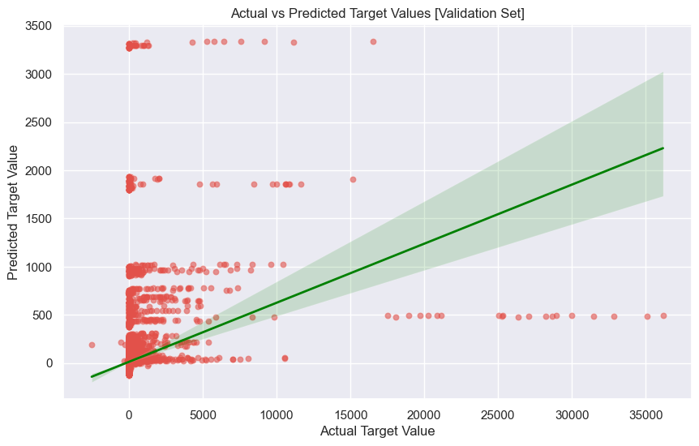

```python
# Creating Scatter Plot and Regression Line for Actual vs Predicted Target Values [Validation Set]

plt.figure(figsize=(10, 6))

# Creating a scatter plot
sns.scatterplot(x=y_validate, y=linear_pred, alpha=0.4)

# Adding a regression line
sns.regplot(x=y_validate, y=linear_pred, truncate=True, scatter_kws={'s': 20, 'alpha': 0.3}, line_kws={'color': 'green', 'linewidth': 2})

# Setting labels and title
plt.xlabel('Actual Target Value')
plt.ylabel('Predicted Target Value')
plt.title("Actual vs Predicted Target Values [Validation Set]")

plt.show()
```

```python
# Training Decision Tree Regressor Model

# Create a Decision Tree Regressor model
model_desc = DecisionTreeRegressor()

# Fit the model on the training dataset
model_desc.fit(X_train, y_train)
```

```
DecisionTreeRegressor()
```

```python
# Evaluating Decision Tree Regressor Model on Validation Data

# Making predictions on the validation dataset using the Decision Tree Regressor model
pred_desc = model_desc.predict(X_validate)

# Calculating RMSE and R-squared score
rmse_desc = np.sqrt(mean_squared_error(y_validate, pred_desc))
r2_score_desc = r2_score(y_validate, pred_desc)

# Printting the evaluation metrics
print(f"RMSE: {rmse_desc}\nR-squared Score: {r2_score_desc}")
```

```
RMSE: 81.3240442591953
R-squared Score: 0.9289937142977992
```

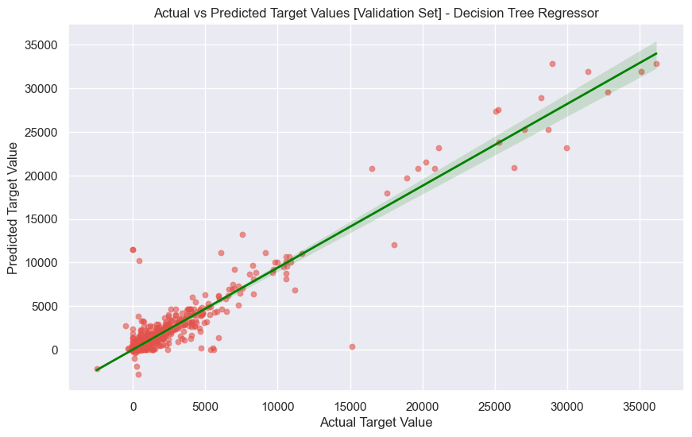

```python
# Creating Scatter Plot and Regression Line for Actual vs Predicted Target Values [Validation Set] - Decision Tree Regressor

plt.figure(figsize=(10, 6))

# Creating a scatter plot
sns.scatterplot(x=y_validate, y=pred_desc, alpha=0.4)

# Adding a regression line
sns.regplot(x=y_validate, y=pred_desc, truncate=True, scatter_kws={'s': 20, 'alpha': 0.3}, line_kws={'color': 'green', 'linewidth': 2})

# Set labels and title
plt.xlabel('Actual Target Value')
plt.ylabel('Predicted Target Value')
plt.title("Actual vs Predicted Target Values [Validation Set] - Decision Tree Regressor")

plt.show()
```

```python
# Create a RandomForestRegressor model with specific parameters
rand_forest_reg = RandomForestRegressor(n_jobs=-1, n_estimators=200)

# Fitting RandomForestRegressor Model to Training Dataset
rand_forest_reg.fit(X_train, y_train)
```

```
RandomForestRegressor(n_estimators=200, n_jobs=-1)
```

```python
# Evaluating RandomForestRegressor Model on Validation Data

# Making predictions on the validation dataset using the RandomForestRegressor model
pred_rand = rand_forest_reg.predict(X_validate)

# Calculating RMSE and R-squared score
rmse_rand = np.sqrt(mean_squared_error(y_validate, pred_rand))
r2_score_rand = r2_score(y_validate, pred_rand)

# Printting the evaluation metrics
print(f"RMSE: {rmse_rand}\nR-squared Score: {r2_score_rand}")
```

```
RMSE: 63.940850094147265
R-squared Score: 0.9561049375431124
```

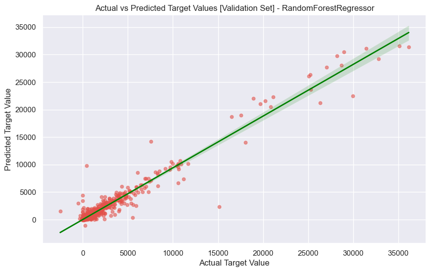

```python
# Creating Scatter Plot and Regression Line for Actual vs Predicted Target Values [Validation Set] - RandomForestRegressor
plt.figure(figsize=(10, 6))

# Creating a scatter plot
sns.scatterplot(x=y_validate, y=pred_rand, alpha=0.4)

# Adding a regression line
sns.regplot(x=y_validate, y=pred_rand, truncate=True, scatter_kws={'s': 20, 'alpha': 0.3}, line_kws={'color': 'green', 'linewidth': 2})

# Setting labels and title
plt.xlabel('Actual Target Value')
plt.ylabel('Predicted Target Value')
plt.title("Actual vs Predicted Target Values [Validation Set] - RandomForestRegressor")

plt.show()
```

```python
## xgbr = XGBRegressor(n_estimator = 1000,learning_rate = 0.01,n_jobs=-1,subsample=0.5,max_depth=5,objective='reg:squarederror')

## XGBoost Regressor Model

# Create an XGBRegressor model with specific parameters
xgbr = XGBRegressor(n_estimators=1000, learning_rate=0.01, n_jobs=-1, subsample=0.5, max_depth=5, objective='reg:squarederror')

# Fit the XGBRegressor model to the training dataset
xgbr.fit(X_train, y_train)

# Make predictions on the validation dataset
pred_xgbr = xgbr.predict(X_validate)

# Evaluate the XGBRegressor model
rmse_xgbr = np.sqrt(mean_squared_error(y_validate, pred_xgbr))
r2_score_xgbr = r2_score(y_validate, pred_xgbr)

# Print the evaluation metrics
print(f"RMSE: {rmse_xgbr}\nR-squared Score: {r2_score_xgbr}")
```

```
RMSE: 94.24617071190389
R-squared Score: 0.9046355987125212
```

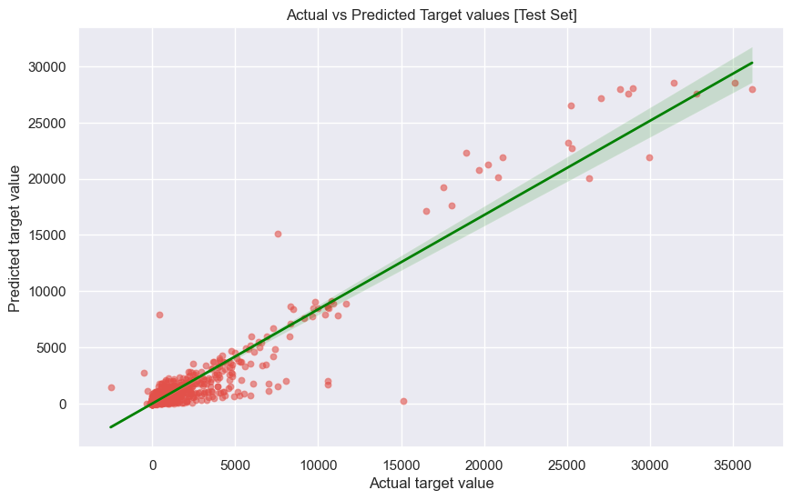

```python
plt.figure(figsize=(10,6))

sns.scatterplot(x=y_validate,y=pred_xgbr,alpha=0.4)

sns.regplot(x=y_validate,y=pred_xgbr,truncate=True,scatter_kws={'s':20,'alpha':0.3},line_kws={'color':'green','linewidth':2})

plt.xlabel('Actual target value')
plt.ylabel('Predicted target value')
plt.title("Actual vs Predicted Target values [Test Set]")

plt.show()
```

```python
sgd_reg = SGDRegressor(max_iter=1000, tol=1e-3, eta0=0.5)
sgd_reg.fit(X_train, y_train)

# Make predictions on the validation dataset
pred_sgd = sgd_reg.predict(X_validate)

# Evaluate the SGDRegressor model
rmse_sgd = np.sqrt(mean_squared_error(y_validate, pred_sgd))
r2_score_sgd = r2_score(y_validate, pred_sgd)

# Print the evaluation metrics
print(f"RMSE: {rmse_sgd}\nR-squared Score: {r2_score_sgd}")
```

```
RMSE: 2.107552382602982e+24
R-squared Score: -4.768871440401429e+43
```

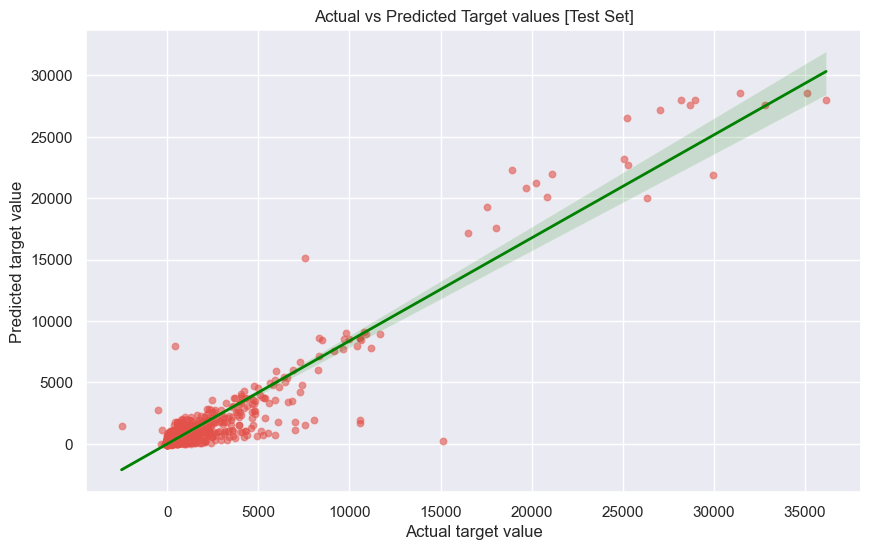

```python
plt.figure(figsize=(10,6))

sns.scatterplot(x=y_validate,y=pred_xgbr,alpha=0.4)

sns.regplot(x=y_validate,y=pred_xgbr,truncate=True,scatter_kws={'s':20,'alpha':0.3},line_kws={'color':'green','linewidth':2})

plt.xlabel('Actual target value')
plt.ylabel('Predicted target value')
plt.title("Actual vs Predicted Target values [Test Set]")


plt.show()
```

## Preprocessing for Test Data

```python
test = test_df.copy()
test = test.drop(['ForecastId', 'County', 'Province_State'], axis=1)
countries = pd.get_dummies(test['Country_Region'])
targets = pd.get_dummies(test['Target'])
mer = pd.concat([test, targets], axis=1)
merged = pd.concat([mer, countries], axis=1)
test = merged.drop(['Target', 'Fatalities', 'Country_Region', 'Afghanistan'], axis=1)
test['Date'] = pd.to_datetime(test['Date'])
```

```python
test.Date = pd.to_datetime(test.Date)
```

```python
# Creating Date-Related Features for Test Data

##  uses the `createDateFeatures` function to add date-related features to the test data (`test`). It then drops the 'Date' column from the dataset.

createDateFeatures(test)
test = test.drop(['Date'], axis=1)
```

```python
## Final Shape of Test Data
test.shape
```

```
(311670, 195)
```

```python
d = test.copy()
```

```python
#d
```

```python
# Handling Missing Values in Test Data

for i in d.columns[d.isnull().any(axis=0)]:
    d[i].fillna(d[i].mean(), inplace=True)
d.shape
```

```
(311670, 195)
```

```python
## Making Predictions on Test Data using RandomForestRegressor Model

# evaluating the random forest regression model on test data-set

pred_rand_test = rand_forest_reg.predict(d)

#rmse_rand_test = np.sqrt(mean_squared_error(d,pred_rand_test))
#r2_score_rand_test= r2_score(d,pred_rand_test)

#print(f"rmse : {rmse_rand_test} \nr2_score : {r2_score_rand_test}")
```

```python
# Descriptive Statistics of Predicted Values
d['TargetValue'] = pred_rand_test
d.describe()
```

|  | Population | Weight | day | month | dayofweek | dayofyear | quarter | weekofyear | TargetValue |
| --- | --- | --- | --- | --- | --- | --- | --- | --- | --- |
| count | 3.116700e+05 | 311670.000000 | 311670.000000 | 311670.000000 | 311670.000000 | 311670.000000 | 311670.0 | 311670.0 | 311670.000000 |
| mean | 2.720127e+06 | 0.530870 | 14.777778 | 5.133333 | 2.866667 | 140.000000 | 2.0 | 20.733333 | 22.036978 |
| std | 3.477775e+07 | 0.451910 | 9.692828 | 0.541603 | 2.006659 | 12.987194 | 0.0 | 1.86667 | 398.200579 |
| min | 8.600000e+01 | 0.047491 | 1.000000 | 4.000000 | 0.000000 | 118.000000 | 2.0 | 18.0 | -1174.720000 |
| 25% | 1.213300e+04 | 0.096838 | 6.000000 | 5.000000 | 1.000000 | 129.000000 | 2.0 | 19.0 | 0.000000 |
| 50% | 3.053100e+04 | 0.349413 | 13.000000 | 5.000000 | 3.000000 | 140.000000 | 2.0 | 21.0 | 0.065000 |
| 75% | 1.056120e+05 | 0.968379 | 24.000000 | 5.000000 | 5.000000 | 151.000000 | 2.0 | 22.0 | 1.070000 |
| max | 1.395773e+09 | 2.239186 | 31.000000 | 6.000000 | 6.000000 | 162.000000 | 2.0 | 24.0 | 31672.580000 |

```python
#Creating Output DataFrame for Submission
output=pd.DataFrame({'id':test_df.ForecastId,
                    'TargetValue':pred_rand_test})
output.rename(columns={'0': 'TargetValue'})
output
```

|  | id | TargetValue |
| --- | --- | --- |
| 0 | 1 | 111.705 |
| 1 | 2 | 4.870 |
| 2 | 3 | 126.450 |
| 3 | 4 | 2.730 |
| 4 | 5 | 138.190 |
| ... | ... | ... |
| 311665 | 311666 | 0.025 |
| 311666 | 311667 | 20.695 |
| 311667 | 311668 | 0.000 |
| 311668 | 311669 | 10.240 |
| 311669 | 311670 | 0.005 |

311670 rows × 2 columns

```python
# Concatenating DataFrames and Adjusting Column Names
# Calculating Quantiles

# Calculating the 5th percentile (q=0.05) for 'TargetValue' grouped by 'id'
first = output.groupby(['id'])['TargetValue'].quantile(q=0.05).reset_index()

# Calculating the 50th percentile (q=0.5/median) for 'TargetValue' grouped by 'id'
mid = output.groupby(['id'])['TargetValue'].quantile(q=0.5).reset_index()

# Calculating the 95th percentile (q=0.95) for 'TargetValue' grouped by 'id'
third = output.groupby(['id'])['TargetValue'].quantile(q=0.95).reset_index()
```

The above codecell demonstrates the calculation of different quantiles (5th, 50th, and 95th percentiles) for the 'TargetValue' column grouped by the 'id' column in the DataFrame output.

```python
# Renaming Columns
# Renaming columns in the first DataFrame
first.columns = ['id', 'q0.05']

# Renaming columns in the mid DataFrame
mid.columns = ['id', 'q0.5']

# Renaming columns in the third DataFrame
third.columns = ['id', 'q0.95']
```

The above codecell demonstrates the renaming of columns in the DataFrames first, mid, and third. The columns are renamed to 'id' and the respective quantile values (q0.05, q0.5, and q0.95).

```python
# Concatenating mid and third DataFrames to the first DataFrame
first = pd.concat([first, mid['q0.5'], third['q0.95']], axis=1)

# Renaming columns for clarity
first.columns = ['id', 'q0.05', 'q0.5', 'q0.95']

# Optionally, adjusting the assignment although it seems unnecessary in this context
first['q0.05'] = first['q0.05']
first['q0.5'] = first['q0.5']
first['q0.95'] = first['q0.95']
```

```python
# Melting the DataFrame

# Melting the DataFrame 'first' to reshape it
sub=pd.melt(first, id_vars=['id'], value_vars=['q0.05','q0.5','q0.95'])
sub
```

|  | id | variable | value |
| --- | --- | --- | --- |
| 0 | 1 | q0.05 | 111.705 |
| 1 | 2 | q0.05 | 4.870 |
| 2 | 3 | q0.05 | 126.450 |
| 3 | 4 | q0.05 | 2.730 |
| 4 | 5 | q0.05 | 138.190 |
| ... | ... | ... | ... |
| 935005 | 311666 | q0.95 | 0.025 |
| 935006 | 311667 | q0.95 | 20.695 |
| 935007 | 311668 | q0.95 | 0.000 |
| 935008 | 311669 | q0.95 | 10.240 |
| 935009 | 311670 | q0.95 | 0.005 |

935010 rows × 3 columns

```python
# Manipulating Columns in DataFrame

# Replace "q" with an empty string in the 'variable' column
sub['variable'] = sub['variable'].str.replace("q", "", regex=False)

# Create a new column 'ForecastId_Quantile' by combining 'id' and 'variable'
sub['ForecastId_Quantile'] = sub['id'].astype(str) + '_' + sub['variable']

# Assign the values from the 'value' column to the 'TargetValue' column
sub['TargetValue'] = sub['value']
```

```python
# Select only the 'ForecastId_Quantile' and 'TargetValue' columns
sub = sub[['ForecastId_Quantile', 'TargetValue']]

# Reset the index with drop=True to discard the old index
sub.reset_index(drop=True, inplace=True)
```

```python
sub
```

|  | ForecastId_Quantile | TargetValue |
| --- | --- | --- |
| 0 | 1_0.05 | 111.705 |
| 1 | 2_0.05 | 4.870 |
| 2 | 3_0.05 | 126.450 |
| 3 | 4_0.05 | 2.730 |
| 4 | 5_0.05 | 138.190 |
| ... | ... | ... |
| 935005 | 311666_0.95 | 0.025 |
| 935006 | 311667_0.95 | 20.695 |
| 935007 | 311668_0.95 | 0.000 |
| 935008 | 311669_0.95 | 10.240 |
| 935009 | 311670_0.95 | 0.005 |

935010 rows × 2 columns

```python
# Data Preprocessing


# Droping 'County' and 'Province_State' columns from the original DataFrame
df = train_df.drop(['County', 'Province_State'], axis=1)

# Creating dummy variables for 'Target' and 'Country_Region' columns
dummies = pd.get_dummies(df['Target'])
dummies_country = pd.get_dummies(df['Country_Region'])

# Concatenating the original DataFrame with dummy variables
merged = pd.concat([df, dummies], axis='columns')
merged = pd.concat([merged, dummies_country], axis='columns')

# Droping specified columns from the merged DataFrame
df_without_text_target = merged.drop(['Target', 'Afghanistan', 'Country_Region'], axis=1)
```

```python
# Preprocessing for the Final DataFrame


# Droping the 'Fatalities' column from df_without_text_target
df_final = df_without_text_target.drop(['Fatalities'], axis='columns')

# Converting 'Date' column to datetime format
df_final['Date'] = pd.to_datetime(df_final['Date'])

# Creating a Function to create date-related features
def createDateFeatures(df):
    return df

# Apply the function to create date-related features
createDateFeatures(df_final)
```

|  | Id | Population | Weight | Date | TargetValue | ConfirmedCases | Albania | Algeria | Andorra | Angola | ... | United Kingdom | Uruguay | Uzbekistan | Venezuela | Vietnam | West Bank and Gaza | Western Sahara | Yemen | Zambia | Zimbabwe |
| --- | --- | --- | --- | --- | --- | --- | --- | --- | --- | --- | --- | --- | --- | --- | --- | --- | --- | --- | --- | --- | --- |
| 0 | 1 | 27657145 | 0.058359 | 2020-01-23 | 0 | True | False | False | False | False | ... | False | False | False | False | False | False | False | False | False | False |
| 1 | 2 | 27657145 | 0.583587 | 2020-01-23 | 0 | False | False | False | False | False | ... | False | False | False | False | False | False | False | False | False | False |
| 2 | 3 | 27657145 | 0.058359 | 2020-01-24 | 0 | True | False | False | False | False | ... | False | False | False | False | False | False | False | False | False | False |
| 3 | 4 | 27657145 | 0.583587 | 2020-01-24 | 0 | False | False | False | False | False | ... | False | False | False | False | False | False | False | False | False | False |
| 4 | 5 | 27657145 | 0.058359 | 2020-01-25 | 0 | True | False | False | False | False | ... | False | False | False | False | False | False | False | False | False | False |
| ... | ... | ... | ... | ... | ... | ... | ... | ... | ... | ... | ... | ... | ... | ... | ... | ... | ... | ... | ... | ... | ... |
| 969635 | 969636 | 14240168 | 0.607106 | 2020-06-08 | 0 | False | False | False | False | False | ... | False | False | False | False | False | False | False | False | False | True |
| 969636 | 969637 | 14240168 | 0.060711 | 2020-06-09 | 27 | True | False | False | False | False | ... | False | False | False | False | False | False | False | False | False | True |
| 969637 | 969638 | 14240168 | 0.607106 | 2020-06-09 | 0 | False | False | False | False | False | ... | False | False | False | False | False | False | False | False | False | True |
| 969638 | 969639 | 14240168 | 0.060711 | 2020-06-10 | 6 | True | False | False | False | False | ... | False | False | False | False | False | False | False | False | False | True |
| 969639 | 969640 | 14240168 | 0.607106 | 2020-06-10 | 0 | False | False | False | False | False | ... | False | False | False | False | False | False | False | False | False | True |

969640 rows × 192 columns

## Model Training and Evaluation

```python
# Model Training and Evaluation


# Separating features and target variable
X = df_final.drop(['Id', 'Date', 'TargetValue'], axis='columns')
y = df_final['TargetValue']

# Splitting the data into training and validation sets
X_train, X_validate, y_train, y_validate = train_test_split(X, y, test_size=0.22, random_state=0)

# Listing of Regression Models
models = [LinearRegression(), DecisionTreeRegressor(), Lasso(alpha=0.1), RandomForestRegressor(n_jobs=-1, n_estimators=200)]

# Iterating over models
for model in models:
    # Constructing a pipeline with standard scaling
    pipe = Pipeline([('scaler', StandardScaler()), ('model', model)])

    # Fitting the model to the training data
    pipe.fit(X_train, y_train)

    # Predicting on the validation set
    prediction = pipe.predict(X_validate)

    # Model Evaluation
    r2_score_val = r2_score(y_validate, prediction)
    rmse_val = math.sqrt(mean_squared_error(y_validate, prediction))

    # Printing model evaluation metrics
    print(f"Model: {model.__class__.__name__}, R2 Score: {r2_score_val}, RMSE: {rmse_val}")
```

```
Model: LinearRegression, R2 Score: 0.0477088062459039, RMSE: 297.8210938500086
Model: DecisionTreeRegressor, R2 Score: 0.5545585427131117, RMSE: 203.6882080477125
Model: Lasso, R2 Score: 0.047673277425580474, RMSE: 297.8266494686628
Model: RandomForestRegressor, R2 Score: 0.553992680838415, RMSE: 203.81754357314145
```

## Preprocessing for Test Data

```python
# Creating a copy of the test_df DataFrame
test = test_df.copy()

# Droping unwanted columns from the test DataFrame
test = test.drop(['ForecastId', 'County', 'Province_State'], axis=1)

# Creating dummy variables for 'Country_Region' and 'Target' columns
countries = pd.get_dummies(test['Country_Region'])
targets = pd.get_dummies(test['Target'])

# Concatenating dummy variables with the test DataFrame
merged = pd.concat([test, targets], axis=1)
merged = pd.concat([merged, countries], axis=1)

# Droping specified columns from the merged DataFrame
test = merged.drop(['Target', 'Fatalities', 'Country_Region', 'Afghanistan'], axis=1)

# Converting 'Date' column to datetime format
test['Date'] = pd.to_datetime(test['Date'])

# Creating date-related features
createDateFeatures(test)

# Droping the 'Date' column after creating date-related features
test = test.drop(['Date'], axis=1)
```

```python
X_test = test.copy()


model = RandomForestRegressor(n_jobs=-1, n_estimators=200)

pipe = Pipeline([('scaler', StandardScaler()), ('model', model)])

# Fitting the model to the entire training data
pipe.fit(X, y)

# Making predictions on the test set
predictions = pipe.predict(X_test)

# Creating a DataFrame with the results
results_df = pd.DataFrame({'ForecastId': test_df['ForecastId'], 'Predicted_Value': predictions})
```

```python
# Displaying the results
results_df.head()
```

|  | ForecastId | Predicted_Value |
| --- | --- | --- |
| 0 | 1 | 156.090760 |
| 1 | 2 | 2.885087 |
| 2 | 3 | 156.090760 |
| 3 | 4 | 2.885087 |
| 4 | 5 | 156.090760 |

```python
results_df.to_csv('predicted_results.csv', index=False)
```

Understanding the Output:

The output is a DataFrame named results_df, which consists of two columns: ForecastId and Predicted_Value. ForecastId: This column likely represents unique identifiers for each data point or prediction instance in the test set. These IDs help in tracking and aligning the predictions with the original test data.

Predicted_Value: This column contains the values predicted by the model. these values represent the forecasted COVID-19 confirmed cases or fatalities.

Usage of Predictions: These predictions could be used by healthcare systems, policymakers, or researchers to understand potential future trends of the COVID-19 pandemic. They could assist in resource allocation, planning for healthcare facilities, and understanding the effectiveness of interventions like lockdowns or vaccination drives.